# Лабораторная работа № 5. Настройка рабочей среды

НПИбд-03-25

Author

Чжу Ино

Published

2026-10-14

# 1 Цель работы

Настройка рабочей среды: менеджер паролей pass, управление файлами конфигурации chezmoi, дополнительное программное обеспечение.

# 2 Задачи

1. Установить и настроить менеджер паролей pass.
2. Освоить управление файлами конфигурации с помощью chezmoi.
3. Установить дополнительное программное обеспечение.

# 3 Теоретические сведения

## 3.1 Менеджер паролей pass

- `pass` — программа, сделанная в рамках идеологии Unix.
- Данные хранятся в файловой системе в виде каталогов и файлов.
- Файлы шифруются с помощью GPG-ключа.

## 3.2 Структура базы паролей

- Структура базы может быть произвольной.
- Примеры имён файлов:
  - `example.com.pgp`
  - `example.com/user.pgp`
  - `user@example.com.pgp`
  - `example.com:22.pgp`

## 3.3 Управление файлами конфигурации chezmoi

- `chezmoi` используется для управления файлами конфигурации домашнего каталога пользователя.
- Состояние файлов конфигурации сохраняется в каталоге `~/.local/share/chezmoi`.
- Файл конфигурации `~/.config/chezmoi/chezmoi.toml`.

# 4 Выполнение лабораторной работы

## 4.1 Установка pass

```bash
sudo dnf -y install pass pass-otp
pass --version
```

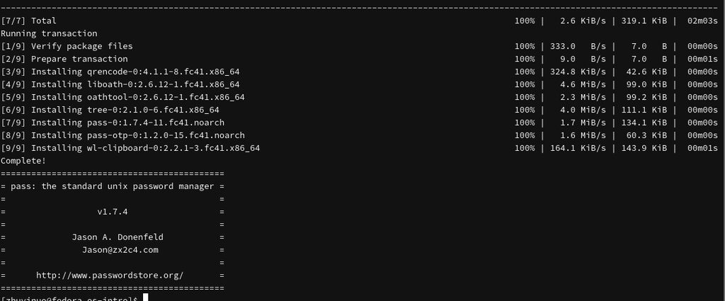

Figure 1: Установка pass

## 4.2 Установка gopass

```bash
sudo dnf -y install gopass
gopass --version
```

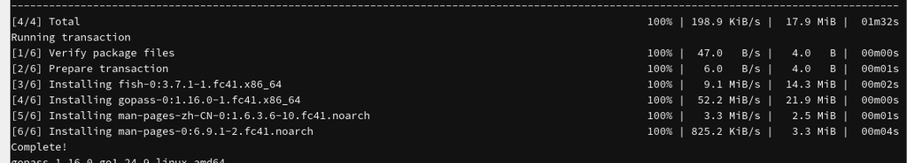

Figure 2: Установка gopass

## 4.3 Ключи GPG

```bash
gpg --list-secret-keys
```

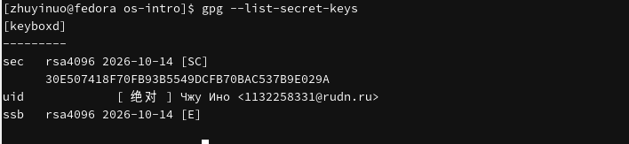

Figure 3: Ключи GPG

## 4.4 Инициализация pass

```bash
pass init 1132258331@rudn.ru
```

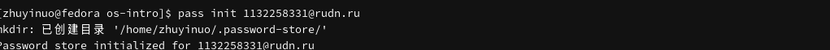

Figure 4: Инициализация pass

## 4.5 Синхронизация с git

```bash
pass git init
gh repo create password-store --private
pass git remote add origin git@github.com:cedar-95/password-store.git
pass git push -u origin master
```

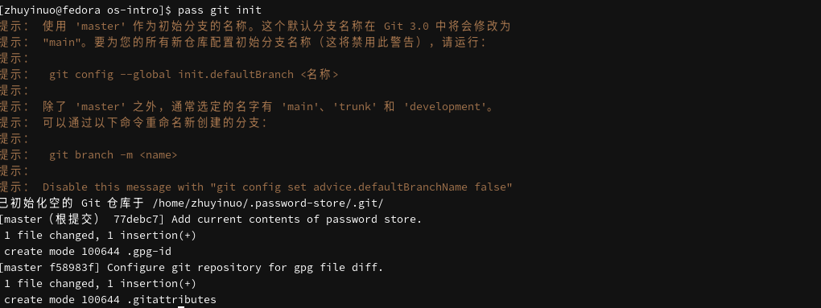

Figure 5: pass git init

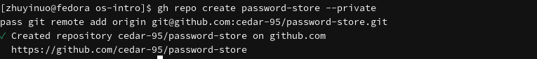

Figure 6: Создание репозитория

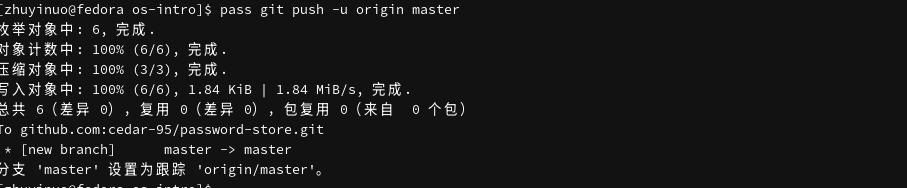

Figure 7: Пуш

## 4.6 Установка chezmoi

```bash
sudo dnf -y install chezmoi
chezmoi --version
```

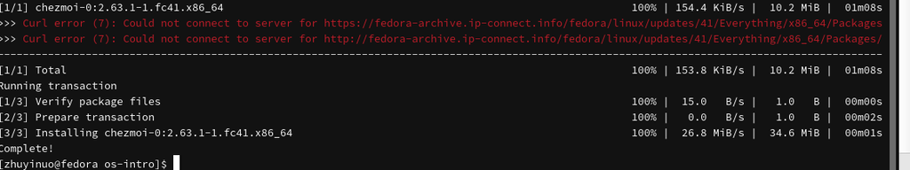

Figure 8: Установка chezmoi

## 4.7 Дополнительное ПО

```bash
sudo dnf -y install \
    dunst \
    fontawesome-fonts \
    powerline-fonts \
    light \
    fuzzel \
    swaylock \
    kitty \
    waybar swaybg \
    wl-clipboard \
    grim \
    slurp
```

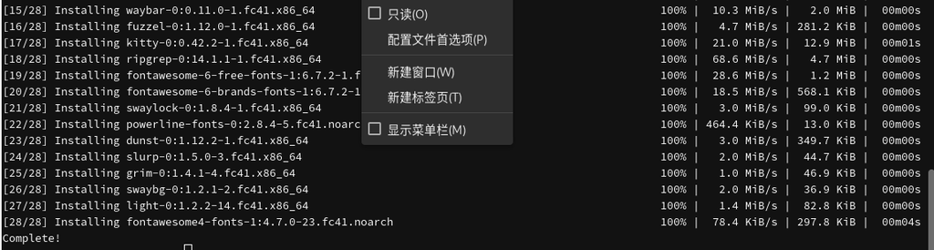

Figure 9: Дополнительное ПО

## 4.8 Создание репозитория dotfiles

```bash
gh repo create dotfiles --template="yamadharma/dotfiles-template" --private
```

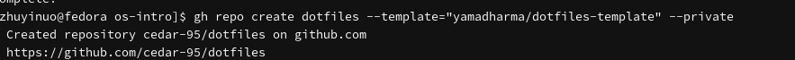

Figure 10: Создание dotfiles

## 4.9 Инициализация chezmoi

```bash
chezmoi init git@github.com:cedar-95/dotfiles.git
chezmoi diff
chezmoi apply -v
```

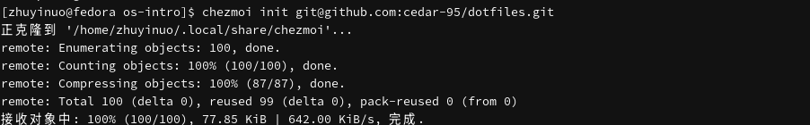

Figure 11: chezmoi init

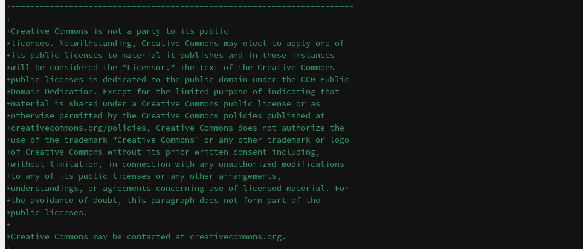

Figure 12: chezmoi diff

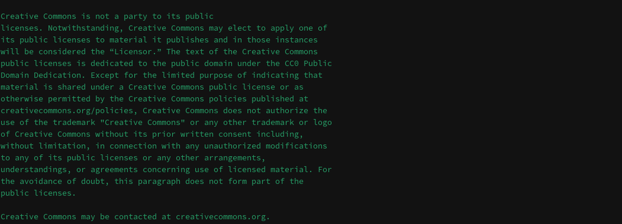

Figure 13: chezmoi apply

## 4.10 Статус chezmoi

```bash
chezmoi managed
chezmoi status
```

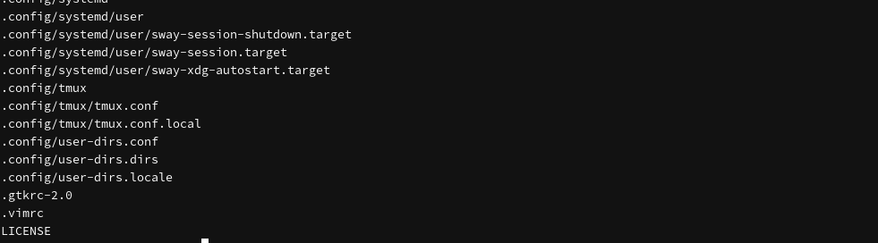

Figure 14: Статус chezmoi

## 4.11 Сохранение пароля

```bash
pass insert example.com/user
```

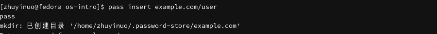

Figure 15: Сохранение пароля

```bash
pass example.com/user
```

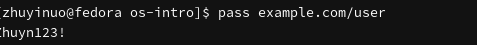

Figure 16: Просмотр пароля

## 4.12 Репозитории на GitHub

[figure not shown]

Figure 17: Репозитории

# 5 Выводы

В ходе работы освоены навыки настройки рабочей среды: установлен и настроен менеджер паролей pass, освоено управление файлами конфигурации с помощью chezmoi, установлено дополнительное программное обеспечение.

# 6 Контрольные вопросы

**1. Что такое менеджер паролей pass?**

`pass` — программа для хранения паролей, использующая файловую систему и GPG-шифрование.

**2. Как хранятся данные в pass?**

В файловой системе в виде каталогов и файлов, зашифрованных GPG.

**3. Какие есть реализации pass?**

- `pass` — классическая реализация на shell.
- `gopass` — реализация на Go.

**4. Что такое chezmoi?**

`chezmoi` — утилита для управления файлами конфигурации домашнего каталога.

**5. Где хранится состояние chezmoi?**

В каталоге `~/.local/share/chezmoi`.

**6. Как инициализировать chezmoi?**

```bash
chezmoi init git@github.com:<username>/dotfiles.git
```

**7. Как применить изменения chezmoi?**

```bash
chezmoi apply -v
```

**8. Как посмотреть различия chezmoi?**

```bash
chezmoi diff
```

**9. Что такое dotfiles?**

Файлы конфигурации в домашнем каталоге (`.bashrc`, `.vimrc` и т. д.).

**10. Зачем нужно дополнительное ПО?**

Для настройки рабочей среды: уведомления, шрифты, блокировка экрана, работа с буфером обмена.

# 7 Список литературы

1. Уокер Д. Управление конфигурацией с помощью chezmoi. — 2023.
2. Чакон С., Штрауб Б. Git для профессионального программиста. — СПб. : Питер, 2016.
3. Колисниченко Д. Н. Самоучитель системного администратора Linux. — БХВ-Петербург, 2011.